# Exploratory Data Analysis (EDA) & Statistical Visualization

Exploratory Data Analysis (EDA), Statistical Graphics, Univariate Analysis (Histograms, Box Plots, Density Plots), Bivariate Analysis (Scatter Plots, Correlation Matrices, Bar Plots), Multivariate Analysis (Pair Plots, Facet Grids), Hypothesis Generation from Visuals, Anscombe's Quartet.

### **Objectives:**

- Students will understand EDA's role as a foundational, hypothesis-generating step in the data mining pipeline.
- Students will perform **univariate analysis** to understand the distribution, central tendency, and spread of individual variables.
- Students will conduct **bivariate analysis** to explore and quantify relationships between pairs of variables (numeric-numeric, numeric-categorical, categorical-categorical).
- Students will utilize **multivariate visualization techniques** like `pairplot` and `FacetGrid` to analyze complex interactions between multiple variables simultaneously.
- Students will learn to move from visual insights to framing testable **statistical hypotheses**.
- Students will master the use of `matplotlib` and `seaborn` for creating a wide range of publication-quality statistical plots.
- Students will critically discuss the importance of visualization over summary statistics, citing examples like Anscombe's Quartet.

### **Setup: Install and Import Libraries**

```python
# Install necessary libraries if not already present in Colab environment
!pip install pandas numpy scikit-learn matplotlib seaborn scipy -q

# Import libraries
import pandas as pd
import numpy as np
import matplotlib.pyplot as plt
import seaborn as sns
import scipy.stats as stats
import sklearn

# Set plot style for better aesthetics
sns.set_theme(style="whitegrid")

# Suppress warnings for cleaner output
import warnings
warnings.filterwarnings('ignore')

print(f"Pandas Version: {pd.__version__}")
print(f"Seaborn Version: {sns.__version__}")
print(f"Scikit-learn Version: {sklearn.__version__}")
```

```
Pandas Version: 2.2.2
Seaborn Version: 0.13.2
Scikit-learn Version: 1.6.1
```

### **Part 1: Dataset Loading and Initial Inspection**

We will use the **"tips" dataset**, a classic and intuitive dataset built into the Seaborn library. It records tips given in a restaurant over a period of time and includes details about the tipper. Its simplicity and mix of data types make it ideal for demonstrating a wide array of EDA techniques.

**Tasks:**

- Load the dataset.
- Perform an initial inspection using `.info()`, `.describe()`, and `.head()` to understand its structure and content.

```python
print("--- Part 1: Dataset Loading and Initial Inspection ---")

# 1. Load the "tips" dataset from seaborn
tips = sns.load_dataset('tips')

# 2. Initial inspection
print("--- Dataset Info ---")
tips.info()

print("\n--- First 5 Rows ---")
print(tips.head())

print("\n--- Summary Statistics for Numerical Features ---")
print(tips.describe())

print("\n--- Value Counts for Categorical Features ---")
print(tips['day'].value_counts())
```

```
--- Part 1: Dataset Loading and Initial Inspection ---
--- Dataset Info ---
<class 'pandas.core.frame.DataFrame'>
RangeIndex: 244 entries, 0 to 243
Data columns (total 7 columns):
 #   Column      Non-Null Count  Dtype
---  ------      --------------  -----
 0   total_bill  244 non-null    float64
 1   tip         244 non-null    float64
 2   sex         244 non-null    category
 3   smoker      244 non-null    category
 4   day         244 non-null    category
 5   time        244 non-null    category
 6   size        244 non-null    int64
dtypes: category(4), float64(2), int64(1)
memory usage: 7.4 KB

--- First 5 Rows ---
   total_bill   tip     sex smoker  day    time  size
0       16.99  1.01  Female     No  Sun  Dinner     2
1       10.34  1.66    Male     No  Sun  Dinner     3
2       21.01  3.50    Male     No  Sun  Dinner     3
3       23.68  3.31    Male     No  Sun  Dinner     2
4       24.59  3.61  Female     No  Sun  Dinner     4

--- Summary Statistics for Numerical Features ---
       total_bill         tip        size
count  244.000000  244.000000  244.000000
mean    19.785943    2.998279    2.569672
std      8.902412    1.383638    0.951100
min      3.070000    1.000000    1.000000
25%     13.347500    2.000000    2.000000
50%     17.795000    2.900000    2.000000
75%     24.127500    3.562500    3.000000
max     50.810000   10.000000    6.000000

--- Value Counts for Categorical Features ---
day
Sat     87
Sun     76
Thur    62
Fri     19
Name: count, dtype: int64
```

### **Part 2: Univariate Analysis (Understanding Individual Features)**

The first step in any EDA is to understand each feature in isolation. For numerical variables, we want to see their distribution, central tendency, and spread. For categorical variables, we want to see the frequency of each category.

```
--- Part 2: Univariate Analysis ---
```

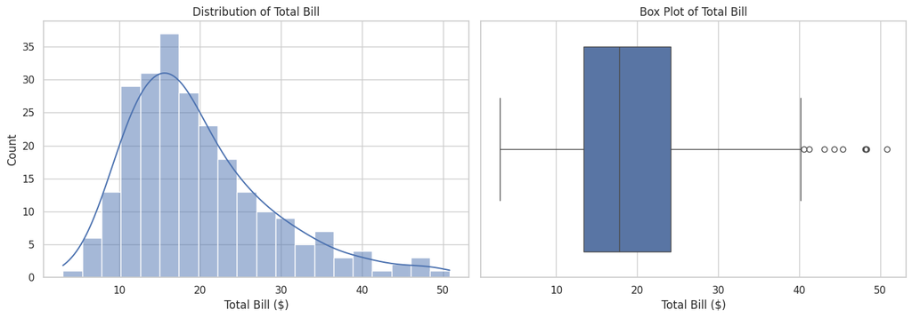

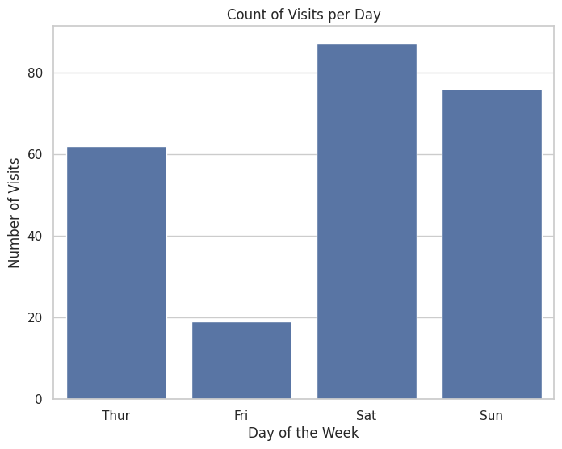

```python
print("\n--- Part 2: Univariate Analysis ---")

# 1. Analyzing a Numerical Feature: 'total_bill'
plt.figure(figsize=(14, 5))

# Histogram with Kernel Density Estimate (KDE)
plt.subplot(1, 2, 1)
sns.histplot(tips['total_bill'], kde=True, bins=20)
plt.title('Distribution of Total Bill')
plt.xlabel('Total Bill ($)')

# Box Plot to show quartiles and outliers
plt.subplot(1, 2, 2)
sns.boxplot(x=tips['total_bill'])
plt.title('Box Plot of Total Bill')
plt.xlabel('Total Bill ($)')

plt.tight_layout()
plt.show()
# INSIGHT: The 'total_bill' is right-skewed with several outliers on the higher end.

# 2. Analyzing a Categorical Feature: 'day'
plt.figure(figsize=(8, 6))
sns.countplot(x='day', data=tips, order=['Thur', 'Fri', 'Sat', 'Sun'])
plt.title('Count of Visits per Day')
plt.xlabel('Day of the Week')
plt.ylabel('Number of Visits')
plt.show()
# INSIGHT: The restaurant is busiest on Saturday and Sunday.
```

### **Part 3: Bivariate Analysis (Exploring Relationships Between Two Features)**

This is where we start looking for relationships. We will explore three types of relationships: numerical-numerical, numerical-categorical, and categorical-categorical.

**Tasks:**

- Analyze the relationship between `total_bill` and `tip` (numeric-numeric).
- Analyze how `tip` amount varies by `day` (numeric-categorical).
- Visualize the correlation of all numerical features using a heatmap.

```
--- Part 3: Bivariate Analysis ---
```

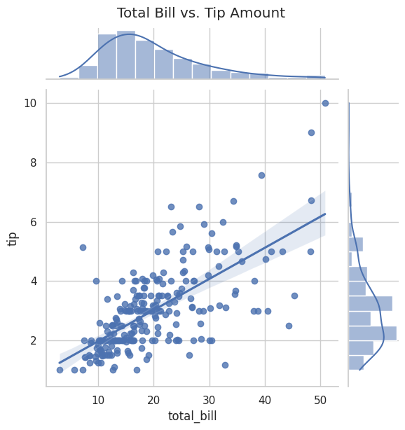

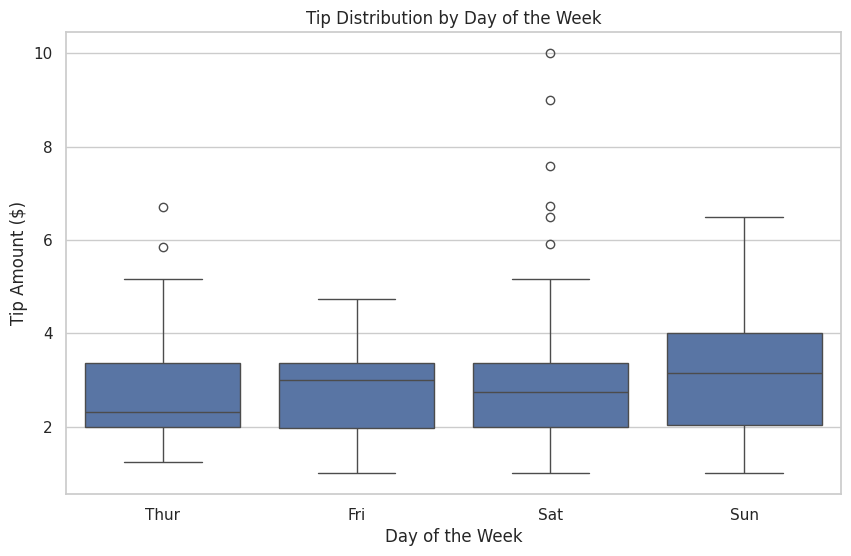

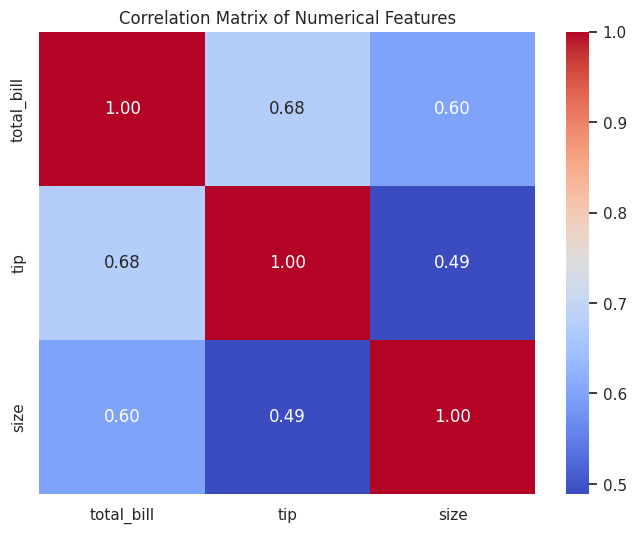

```python
print("\n--- Part 3: Bivariate Analysis ---")

# 1. Numeric vs. Numeric: 'total_bill' vs 'tip'
# A scatter plot is the best choice to see the relationship
sns.jointplot(x='total_bill', y='tip', data=tips, kind='reg') # 'reg' adds a regression line
plt.suptitle('Total Bill vs. Tip Amount', y=1.02)
plt.show()
# INSIGHT: There is a strong, positive linear relationship. As the bill increases, the tip tends to increase.

# 2. Numeric vs. Categorical: 'day' vs 'tip'
# A box plot or violin plot is great for comparing distributions across categories
plt.figure(figsize=(10, 6))
sns.boxplot(x='day', y='tip', data=tips, order=['Thur', 'Fri', 'Sat', 'Sun'])
plt.title('Tip Distribution by Day of the Week')
plt.xlabel('Day of the Week')
plt.ylabel('Tip Amount ($)')
plt.show()
# INSIGHT: Median tips are slightly higher on weekends, though the spread is also larger.

# 3. Correlation Heatmap for all numerical features
# First, calculate the correlation matrix
correlation_matrix = tips[['total_bill', 'tip', 'size']].corr()

plt.figure(figsize=(8, 6))
sns.heatmap(correlation_matrix, annot=True, cmap='coolwarm', fmt=".2f")
plt.title('Correlation Matrix of Numerical Features')
plt.show()
# INSIGHT: Confirms the strong positive correlation between 'total_bill' and 'tip' (0.68). 'size' of the party is also strongly correlated.
```

### **Part 4: Multivariate Analysis (Visualizing Complex Interactions)**

Often, the most interesting insights come from understanding how three or more variables interact. We can use visual attributes like `hue` (color), `style`, and `size`, or create subplots using `facets`.

```
--- Part 4: Multivariate Analysis ---
```

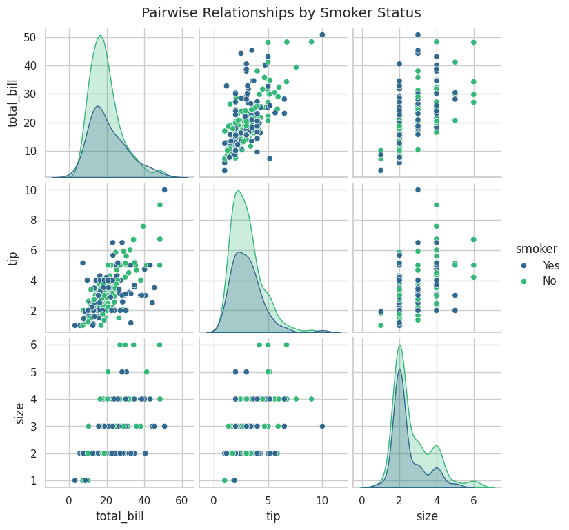

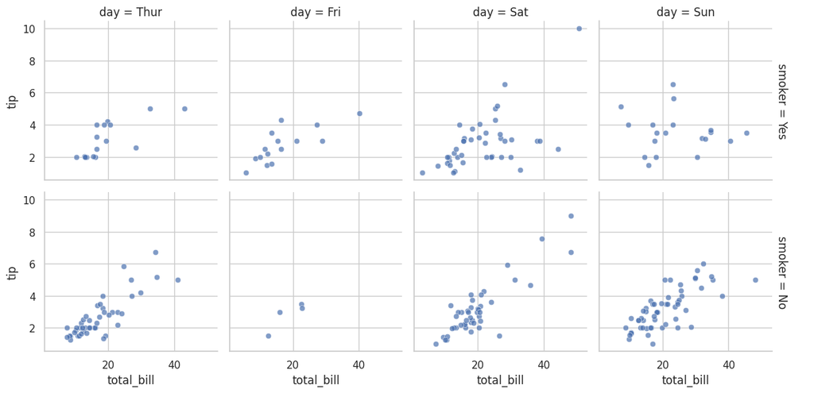

```python
print("\n--- Part 4: Multivariate Analysis ---")

# 1. Pair Plot to see all pairwise relationships
# Using 'hue' adds a third dimension (a categorical one) to the plots
sns.pairplot(tips, hue='smoker', palette='viridis')
plt.suptitle('Pairwise Relationships by Smoker Status', y=1.02)
plt.show()
# INSIGHT: This gives a rapid, high-level overview. We can quickly see that the distributions for smokers and non-smokers
# are largely overlapping, but there might be subtle differences in the 'total_bill' vs 'tip' relationship.

# 2. Facet Grid to analyze interactions
# Here we examine 'total_bill' vs 'tip' but create separate plots for each combination of 'day' and 'smoker'
g = sns.FacetGrid(tips, col="day", row="smoker", margin_titles=True)
g.map(sns.scatterplot, "total_bill", "tip", alpha=.7)
g.add_legend()
plt.show()
# INSIGHT: This is a powerful visualization. For example, we can see the relationship on Sunday for non-smokers
# seems tighter than for smokers. This detailed view allows for more nuanced hypothesis generation.
```

### **Part 5: From Visualization to Hypothesis Testing**

The primary goal of EDA is to generate questions and hypotheses that can be formally tested. Our visualizations suggest several interesting relationships. Let's frame one and perform a simple statistical test.

**Hypothesis:** Based on the boxplots, it appears that tips are different on weekends vs. weekdays. Let's formally state this:

- **Null Hypothesis ($H_0$)**: The mean tip amount on Saturday is the same as the mean tip amount on Thursday.
- **Alternative Hypothesis ($H_a$)**: The mean tip amount on Saturday is different from the mean tip amount on Thursday.

We can use an **Independent Two-Sample T-test** to check this.

```python
print("\n--- Part 5: From Visualization to Hypothesis Testing ---")

# 1. Isolate the data for the two groups we want to compare
tips_sat = tips[tips['day'] == 'Sat']['tip']
tips_thur = tips[tips['day'] == 'Thur']['tip']

# 2. Perform the independent t-test
ttest_result = stats.ttest_ind(tips_sat, tips_thur)

print(f"T-test statistic: {ttest_result.statistic:.4f}")
print(f"P-value: {ttest_result.pvalue:.4f}")

# 3. Interpret the result
alpha = 0.05
if ttest_result.pvalue < alpha:
    print("\nConclusion: We reject the null hypothesis.")
    print("There is a statistically significant difference in tip amounts between Saturday and Thursday.")
else:
    print("\nConclusion: We fail to reject the null hypothesis.")
    print("There is not enough evidence to claim a significant difference in tip amounts.")
```

```
--- Part 5: From Visualization to Hypothesis Testing ---
T-test statistic: 0.9002
P-value: 0.3695

Conclusion: We fail to reject the null hypothesis.
There is not enough evidence to claim a significant difference in tip amounts.
```

### **Part 6: Advanced Topics & Discussion**

- **Anscombe's Quartet:** This famous dataset consists of four sets of (x, y) pairs. If you calculate summary statistics (mean, variance, correlation) for each set, they are nearly identical. However, when you plot them, you see four completely different relationships. This is the classic argument for why you **must visualize your data** before modeling. Relying on statistics alone can be dangerously misleading.
- **Choosing the Right Plot:** The key is to match the plot type to the data types and the question you're asking:
  - **One Variable Distribution:** `histplot` (numeric), `countplot` (categorical).
  - **Two Variable Relationship:** `scatterplot` (numeric-numeric), `boxplot` (numeric-categorical), `heatmap` of a crosstab (categorical-categorical).
  - **Three+ Variable Relationship:** Use `hue`, `style`, `size` parameters, or `FacetGrid`/`pairplot`.
- **Interactive Visualization:** For very complex datasets, static plots can be limiting. Libraries like **Plotly** and **Bokeh** allow you to create interactive visualizations where you can hover for details, zoom, pan, and filter the data on the fly. This enables a much deeper and more intuitive form of exploratory analysis.
- **Avoiding Misleading Visualizations:** A key skill is to create honest and clear visualizations. Be wary of common pitfalls like:
  - Truncating the Y-axis to exaggerate differences.
  - Using 3D pie charts or other chart types that distort proportions.
  - Employing confusing or non-intuitive color schemes. The goal of EDA is to find the truth in the data, not to tell a misleading story.

Prepared By

**Md. Atikuzzaman**  
Lecturer  
Department of Computer Science and Engineering  
Green University of Bangladesh  
Email: atik@cse.green.edu.bd